# 3 Zeitraum

## 3.1 Setup

```r
library(tidyverse)
library(lubridate)
library(gt)
library(visdat)
library(data.table)
#library(collapse)
library(targets)
library(easystats)
library(scales)
```

```r
source("_common.r")
```

```r
tar_load(c(
  course_and_uni_per_visit,
  n_action,
  n_action_w_date,
  time_since_last_visit,
  time_visit_wday,
  n_action_fingerprint,
  time_visit_wday_fingerprint,
  data_separated_filtered,
  n_action_lt_500,
  n_action_lt_500_fingerprint
))
```

## 3.2 Beginn/Ende der Daten

```r
n_action_w_date |>
  head(30)
```

| idvisit | nr_max | date_time_start | month_of_visit | month_date | week_date | week_of_visit | year_of_visit | hour_of_visit_start |
| --- | --- | --- | --- | --- | --- | --- | --- | --- |
| 1 | 157 | 2023-03-23 18:37:56 | Mar | 2023-03-01 | 2023-03-20 | 12 | 2023 | 18 |
| 2 | 11 | 2023-03-23 17:18:10 | Mar | 2023-03-01 | 2023-03-20 | 12 | 2023 | 17 |
| 3 | 8 | 2023-03-23 17:17:36 | Mar | 2023-03-01 | 2023-03-20 | 12 | 2023 | 17 |
| 4 | 107 | 2023-03-23 15:15:59 | Mar | 2023-03-01 | 2023-03-20 | 12 | 2023 | 15 |
| 5 | 24 | 2023-03-23 14:20:12 | Mar | 2023-03-01 | 2023-03-20 | 12 | 2023 | 14 |
| 6 | 1 | 2023-03-23 14:29:42 | Mar | 2023-03-01 | 2023-03-20 | 12 | 2023 | 14 |
| 7 | 12 | 2023-03-24 17:58:33 | Mar | 2023-03-01 | 2023-03-20 | 12 | 2023 | 17 |
| 8 | 10 | 2023-03-24 16:06:55 | Mar | 2023-03-01 | 2023-03-20 | 12 | 2023 | 16 |
| 9 | 6 | 2023-03-24 16:21:10 | Mar | 2023-03-01 | 2023-03-20 | 12 | 2023 | 16 |
| 10 | 60 | 2023-03-24 15:30:36 | Mar | 2023-03-01 | 2023-03-20 | 12 | 2023 | 15 |

[output cut: 20 more lines]

```r
min_max_time <-
  n_action_w_date |>
  summarise(
    time_min = min(date_time_start, na.rm = T),
    time_max = max(date_time_start, na.rm = T)
  )

min_max_time |>
  gt()
```

| time_min | time_max |
| --- | --- |
| 2022-12-05 15:33:45 | 2025-07-14 23:40:45 |

**Wichtig**

Erster Visit im Datensatz: 2022-12-05 15:33:45.

Letzter Visit im Datensatz: 2025-07-14 23:40:45.

## 3.3 Days since last visit

### 3.3.1 Insgesamt

#### 3.3.1.1 idvisit

```r
time_visit_wday |>
  head(30)
```

| idvisit | dow | hour | date_time |
| --- | --- | --- | --- |
| 1 | 4 | 18 | 2023-03-23 18:37:56 |
| 2 | 4 | 17 | 2023-03-23 17:18:10 |
| 3 | 4 | 17 | 2023-03-23 17:17:36 |
| 4 | 4 | 15 | 2023-03-23 15:15:59 |
| 5 | 4 | 14 | 2023-03-23 14:20:12 |
| 6 | 4 | 14 | 2023-03-23 14:29:42 |
| 7 | 5 | 17 | 2023-03-24 17:58:33 |
| 8 | 5 | 16 | 2023-03-24 16:06:55 |
| 9 | 5 | 16 | 2023-03-24 16:21:10 |
| 10 | 5 | 15 | 2023-03-24 15:30:36 |

[output cut: 20 more lines]

```r
time_since_last_visit <-
  time_since_last_visit |>
  mutate(dayssincelastvisit = as.numeric(dayssincelastvisit)) |>
  distinct(idvisit, .keep_all = TRUE)

time_since_last_visit |>
  datawizard::describe_distribution(dayssincelastvisit) |>
  knitr::kable(digits = 2)
```

| Variable | Mean | SD | IQR | Min | Max | Skewness | Kurtosis | n | n_Missing |
| --- | --- | --- | --- | --- | --- | --- | --- | --- | --- |
| dayssincelastvisit | 6.89 | 15.75 | 0 | 1 | 87 | 2.98 | 8.26 | 14207 | 0 |

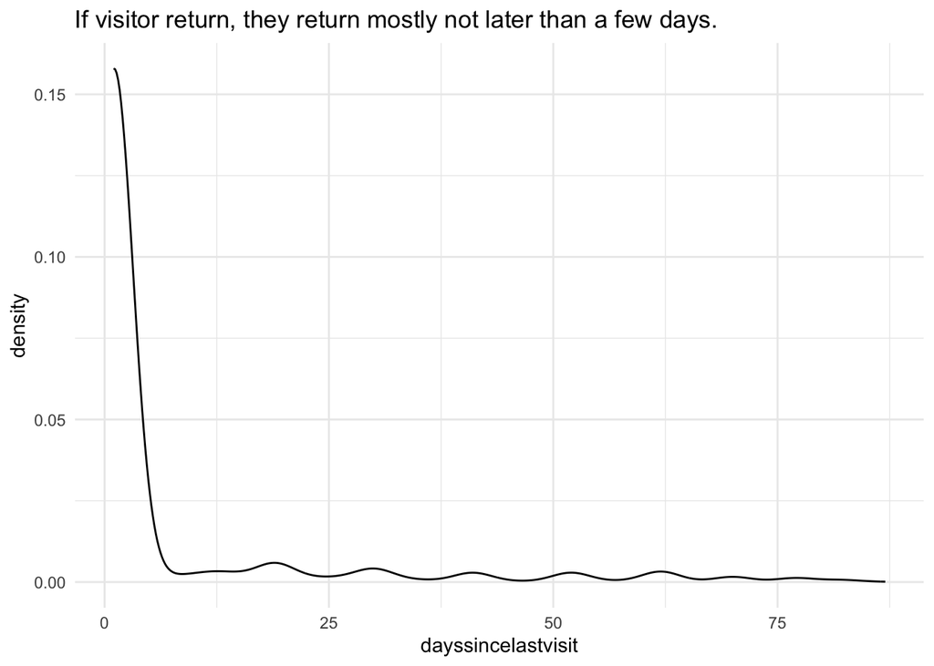

```r
time_since_last_visit |>
  ggplot(aes(x = dayssincelastvisit)) +
  geom_density() +
  labs(
    title = "If visitor return, they return mostly not later than a few days."
  )
```

**Wichtig**

Die Nutzer nutzen die Seite in Abständen von wenigen Tagen?

#### 3.3.1.2 fingerprint unique

```r
time_visit_wday_fingerprint |> head()
```

| fingerprint | dow | hour | date_time |
| --- | --- | --- | --- |
| aa8a78771b4f21ff | 4 | 18 | 2023-03-23 18:37:56 |
| 1f026ad3cbbdf325 | 4 | 17 | 2023-03-23 17:17:36 |
| 518965d4e1ae7e2d | 4 | 14 | 2023-03-23 14:29:42 |
| aa957061ec277742 | 5 | 17 | 2023-03-24 17:58:33 |
| e89126eaae40660e | 5 | 16 | 2023-03-24 16:06:55 |
| 14e1d60a5ac559aa | 5 | 15 | 2023-03-24 15:30:36 |

```r
time_since_last_visit_fingerprint <-
  time_since_last_visit |>
  mutate(dayssincelastvisit = as.numeric(dayssincelastvisit)) |>
  distinct(fingerprint, .keep_all = TRUE)

time_since_last_visit |>
  datawizard::describe_distribution(dayssincelastvisit) |>
  knitr::kable(digits = 2)
```

| Variable | Mean | SD | IQR | Min | Max | Skewness | Kurtosis | n | n_Missing |
| --- | --- | --- | --- | --- | --- | --- | --- | --- | --- |
| dayssincelastvisit | 6.89 | 15.75 | 0 | 1 | 87 | 2.98 | 8.26 | 14207 | 0 |

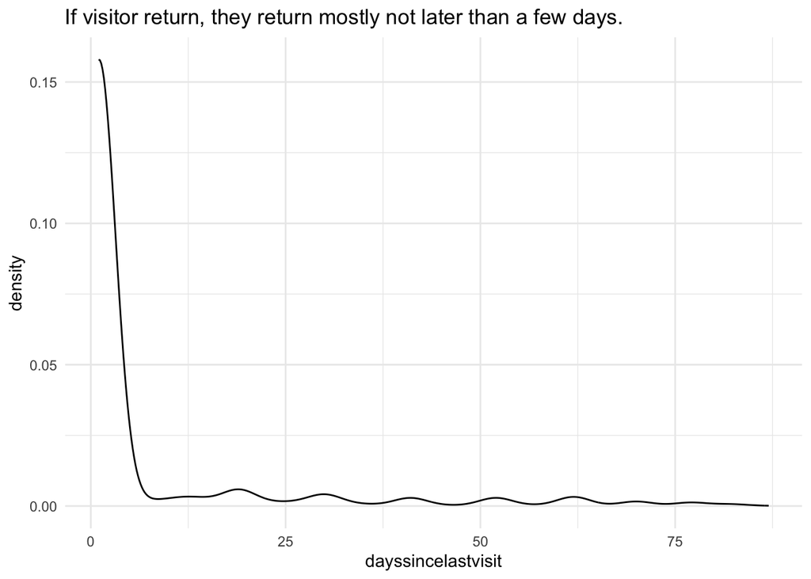

```r
time_since_last_visit |>
  ggplot(aes(x = dayssincelastvisit)) +
  geom_density() +
  labs(
    title = "If visitor return, they return mostly not later than a few days."
  )
```

### 3.3.2 Nach Lehrveranstaltungen

```r
time_since_last_visit_per_course <-
  time_since_last_visit |>
  left_join(course_and_uni_per_visit) |>
  drop_na()
```

```r
time_since_last_visit_per_course_summary <-
  time_since_last_visit_per_course |>
  group_by(course) |>
  summarise(
    dayssincelastvisit_mean = mean(dayssincelastvisit),
    dayssincelastvisit_sd = sd(dayssincelastvisit),
    dayssincelastvisit_n = n()
  ) |>
  mutate(
    dayssincelastvisit_n_log = log(dayssincelastvisit_n, base = 10) + 0.001
  )
```

```r
time_since_last_visit_per_course_summary
```

| course | dayssincelastvisit_mean | dayssincelastvisit_sd | dayssincelastvisit_n | dayssincelastvisit_n_log |
| --- | --- | --- | --- | --- |
| anis2 | 13.023256 | 20.88801 | 43 | 1.6344685 |
| armeufa | 1.000000 | 0.00000 | 2 | 0.3020300 |
| bare | 18.461538 | 22.35925 | 13 | 1.1149434 |
| bio | 8.172619 | 18.18040 | 168 | 2.2263093 |
| biotech | 5.653543 | 13.28107 | 127 | 2.1048037 |
| biovete | 5.864754 | 13.56080 | 244 | 2.3883898 |
| cta1 | 8.670875 | 18.11483 | 1109 | 3.0459315 |
| daba | 12.762626 | 21.09272 | 198 | 2.2976652 |
| enerbi | 9.800000 | 12.42578 | 10 | 1.0010000 |
| epsy | 15.000000 | NA | 1 | 0.0010000 |

[output cut: 18 more lines]

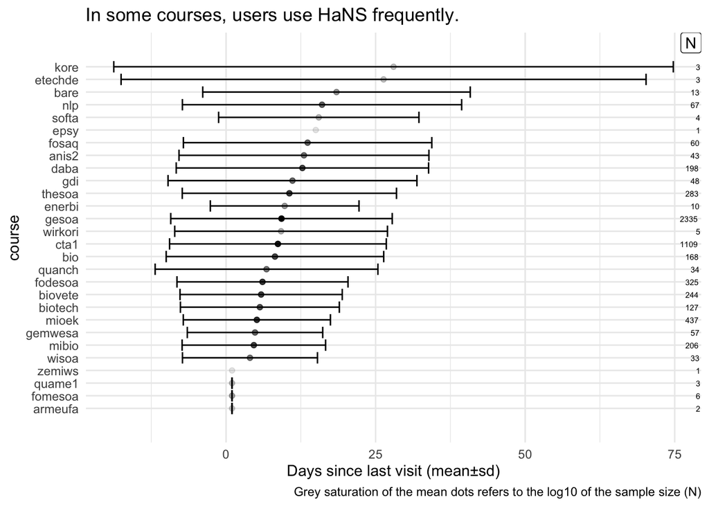

```r
time_since_last_visit_per_course_summary |>
  ggplot(aes(
    y = reorder(course, dayssincelastvisit_mean),
    x = dayssincelastvisit_mean
  )) +
  geom_errorbar(aes(
    xmin = dayssincelastvisit_mean - dayssincelastvisit_sd,
    xmax = dayssincelastvisit_mean + dayssincelastvisit_sd
  )) +
  geom_point(aes(alpha = log(dayssincelastvisit_n)), show.legend = FALSE) +
  labs(
    x = "Days since last visit (mean±sd)",
    y = "course",
    title = "In some courses, users use HaNS frequently.",
    caption = "Grey saturation of the mean dots refers to the log10 of the sample size (N)"
  ) +
  geom_text(
    aes(label = round(dayssincelastvisit_n)),
    x = Inf,
    hjust = 1.2,
    size = 2
  ) +
  annotate(
    x = Inf,
    y = Inf,
    label = "N",
    geom = "label",
    hjust = 1,
    vjust = 1
  ) +
  scale_y_discrete(expand = expansion(mult = 0.1)) +
  theme_minimal()
```

## 3.4 Visits im Zeitverlauf

Wie viele Visits (von Hans) gab es?

### 3.4.1 Visits im Zeitverlauf - üro Monat

#### 3.4.1.1 idivisit

```r
time_visit_wday_summary <-
  time_visit_wday |>
  ungroup() |>
  mutate(month_start = floor_date(date_time, "month")) |>
  mutate(
    month_name = lubridate::month(date_time, label = TRUE, abbr = FALSE),
    month_num = lubridate::month(date_time, label = FALSE),
    year_num = lubridate::year(date_time)
  )
```

```r
time_visit_wday_summary |>
  group_by(year_num, month_num) |>
  summarise(n = n()) |>
  gt()
```

| month_num | n |
| --- | --- |
| 2022 |  |
| 12 | 329 |
| 2023 |  |
| 1 | 455 |
| 2 | 561 |
| 3 | 149 |
| 4 | 253 |
| 5 | 391 |
| 6 | 292 |
| 7 | 441 |
| 8 | 26 |
| 9 | 39 |
| 10 | 614 |
| 11 | 660 |
| 12 | 519 |
| 2024 |  |
| 1 | 783 |
| 2 | 85 |
| 3 | 138 |
| 4 | 329 |
| 5 | 413 |
| 6 | 593 |
| 7 | 743 |
| 8 | 16 |
| 9 | 23 |
| 10 | 731 |
| 11 | 918 |
| 12 | 765 |
| 2025 |  |
| 1 | 959 |
| 2 | 155 |
| 3 | 507 |
| 4 | 1011 |
| 5 | 557 |
| 6 | 321 |
| 7 | 430 |
| NA |  |
| NA | 1 |

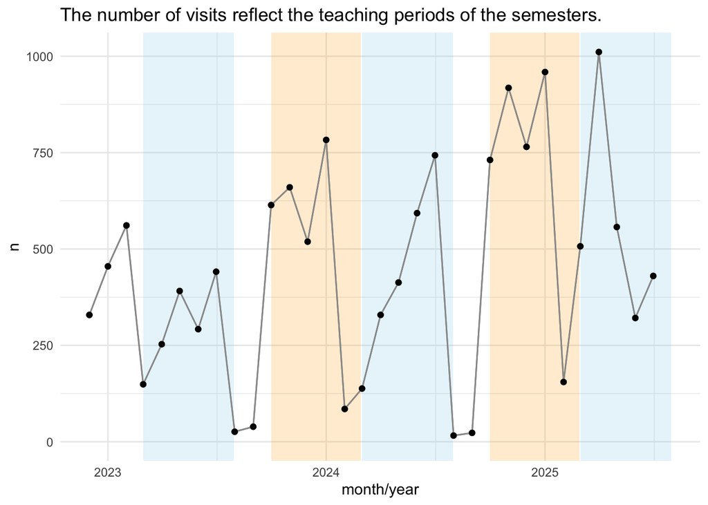

```r
time_visit_wday_summary |>
  group_by(year_num, month_start) |>
  summarise(n = n()) |>
  ggplot(aes(x = month_start, y = n)) +
  geom_line(group = 1, color = "grey60") +
  geom_point() +
  labs(
    title = "The number of visits reflect the teaching periods of the semesters.",
    x = "month/year"
  ) +

  # --- Highlight March–July (approx 1 Mar to 31 Jul) ---
  annotate(
    "rect",
    xmin = as.Date("2023-03-01"),
    xmax = as.Date("2023-07-31"),
    ymin = -Inf,
    ymax = Inf,
    alpha = 0.2,
    fill = "skyblue"
  ) +

  annotate(
    "rect",
    xmin = as.Date("2024-03-01"),
    xmax = as.Date("2024-07-31"),
    ymin = -Inf,
    ymax = Inf,
    alpha = 0.2,
    fill = "skyblue"
  ) +
  annotate(
    "rect",
    xmin = as.Date("2025-03-01"),
    xmax = as.Date("2025-07-31"),
    ymin = -Inf,
    ymax = Inf,
    alpha = 0.2,
    fill = "skyblue"
  ) +

  # --- Highlight October–February (semester break or 2nd term) ---
  annotate(
    "rect",
    xmin = as.Date("2023-10-01"),
    xmax = as.Date("2024-02-28"),
    ymin = -Inf,
    ymax = Inf,
    alpha = 0.2,
    fill = "orange"
  ) +
  # annotate("rect",
  #          xmin = as.Date("2024-10-01"), xmax = as.Date("2024-02-28"),
  #          ymin = -Inf, ymax = Inf, alpha = 0.2, fill = "orange") +
  annotate(
    "rect",
    xmin = as.Date("2024-10-01"),
    xmax = as.Date("2025-02-28"),
    ymin = -Inf,
    ymax = Inf,
    alpha = 0.2,
    fill = "orange"
  ) +

  # --- Your data lines ---
  geom_line(group = 1, color = "grey60") +
  geom_point() +
  labs(
    title = "The number of visits reflect the teaching periods of the semesters.",
    x = "month/year"
  ) +
  theme_minimal()
```

#### 3.4.1.2 fingerprint

```r
time_visit_wday_summary_fingerprint <-
  time_visit_wday_fingerprint |>
  ungroup() |>
  mutate(month_start = floor_date(date_time, "month")) |>
  mutate(
    month_name = lubridate::month(date_time, label = TRUE, abbr = FALSE),
    month_num = lubridate::month(date_time),
    year_num = lubridate::year(date_time)
  )
```

```r
time_visit_wday_summary_fingerprint |>
  group_by(year_num, month_num) |>
  summarise(n = n()) |>
  gt()
```

| month_num | n |
| --- | --- |
| 2022 |  |
| 12 | 235 |
| 2023 |  |
| 1 | 248 |
| 2 | 303 |
| 3 | 99 |
| 4 | 160 |
| 5 | 226 |
| 6 | 195 |
| 7 | 227 |
| 8 | 17 |
| 9 | 23 |
| 10 | 402 |
| 11 | 412 |
| 12 | 325 |
| 2024 |  |
| 1 | 445 |
| 2 | 50 |
| 3 | 94 |
| 4 | 179 |
| 5 | 204 |
| 6 | 274 |
| 7 | 214 |
| 8 | 10 |
| 9 | 16 |
| 10 | 365 |
| 11 | 417 |
| 12 | 317 |
| 2025 |  |
| 1 | 347 |
| 2 | 74 |
| 3 | 217 |
| 4 | 424 |
| 5 | 273 |
| 6 | 171 |
| 7 | 196 |
| NA |  |
| NA | 1 |

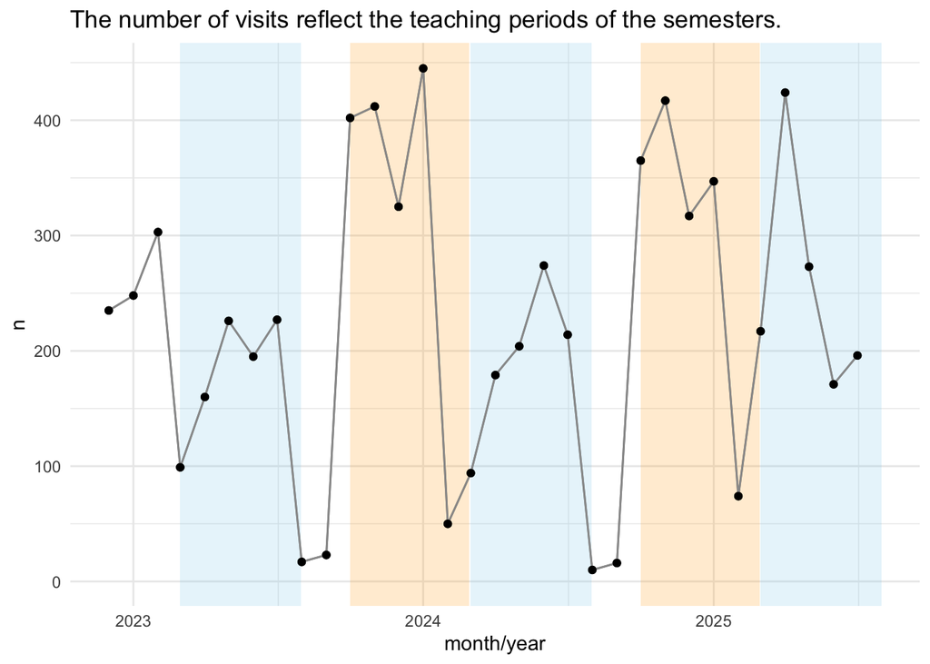

```r
time_visit_wday_summary_fingerprint |>
  group_by(year_num, month_start) |>
  summarise(n = n()) |>
  ggplot(aes(x = month_start, y = n)) +
  geom_line(group = 1, color = "grey60") +
  geom_point() +
  labs(
    title = "The number of visits reflect the teaching periods of the semesters.",
    x = "month/year"
  ) +

  # --- Highlight March–July (approx 1 Mar to 31 Jul) ---
  annotate(
    "rect",
    xmin = as.Date("2023-03-01"),
    xmax = as.Date("2023-07-31"),
    ymin = -Inf,
    ymax = Inf,
    alpha = 0.2,
    fill = "skyblue"
  ) +

  annotate(
    "rect",
    xmin = as.Date("2024-03-01"),
    xmax = as.Date("2024-07-31"),
    ymin = -Inf,
    ymax = Inf,
    alpha = 0.2,
    fill = "skyblue"
  ) +
  annotate(
    "rect",
    xmin = as.Date("2025-03-01"),
    xmax = as.Date("2025-07-31"),
    ymin = -Inf,
    ymax = Inf,
    alpha = 0.2,
    fill = "skyblue"
  ) +

  # --- Highlight October–February (semester break or 2nd term) ---
  annotate(
    "rect",
    xmin = as.Date("2023-10-01"),
    xmax = as.Date("2024-02-28"),
    ymin = -Inf,
    ymax = Inf,
    alpha = 0.2,
    fill = "orange"
  ) +
  # annotate("rect",
  #          xmin = as.Date("2024-10-01"), xmax = as.Date("2024-02-28"),
  #          ymin = -Inf, ymax = Inf, alpha = 0.2, fill = "orange") +
  annotate(
    "rect",
    xmin = as.Date("2024-10-01"),
    xmax = as.Date("2025-02-28"),
    ymin = -Inf,
    ymax = Inf,
    alpha = 0.2,
    fill = "orange"
  ) +

  # --- Your data lines ---
  geom_line(group = 1, color = "grey60") +
  geom_point() +
  labs(
    title = "The number of visits reflect the teaching periods of the semesters.",
    x = "month/year"
  ) +
  theme_minimal()
```

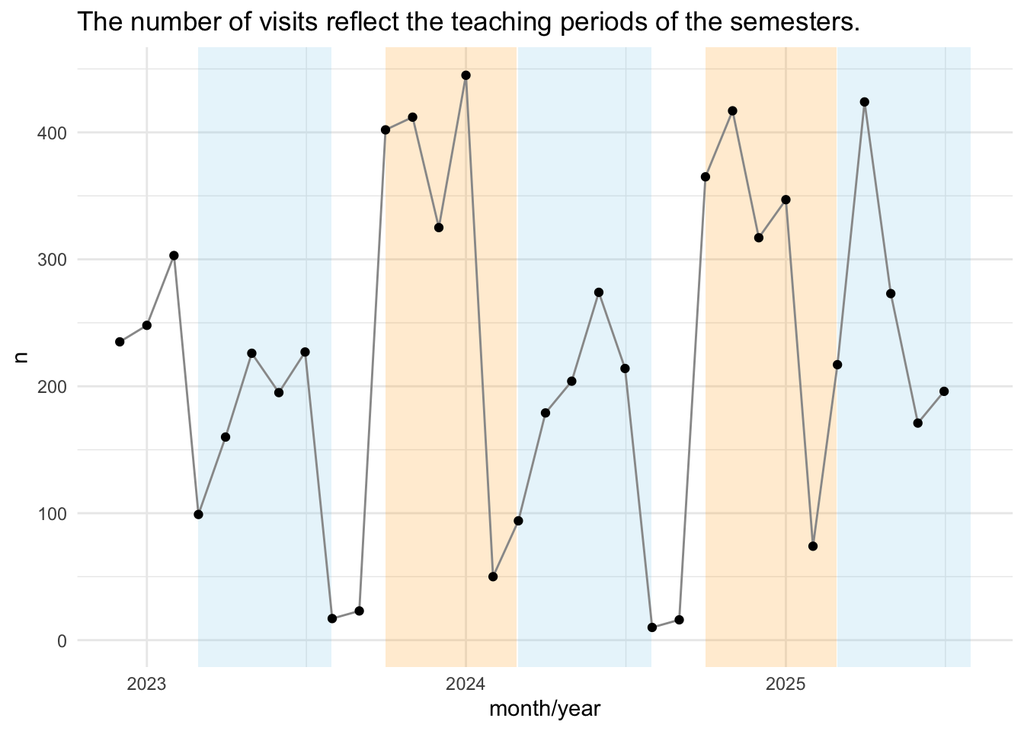

```r
library(ggplot2)
library(dplyr)
library(lubridate)

time_visit_wday_summary_fingerprint |>
  group_by(year_num, month_start) |>
  summarise(n = n()) |>
  ggplot(aes(x = month_start, y = n)) +

  # --- Highlight March–July (approx 1 Mar to 31 Jul) ---
  annotate(
    "rect",
    xmin = as.Date("2023-03-01"),
    xmax = as.Date("2023-07-31"),
    ymin = -Inf,
    ymax = Inf,
    alpha = 0.2,
    fill = "skyblue"
  ) +

  annotate(
    "rect",
    xmin = as.Date("2024-03-01"),
    xmax = as.Date("2024-07-31"),
    ymin = -Inf,
    ymax = Inf,
    alpha = 0.2,
    fill = "skyblue"
  ) +
  annotate(
    "rect",
    xmin = as.Date("2025-03-01"),
    xmax = as.Date("2025-07-31"),
    ymin = -Inf,
    ymax = Inf,
    alpha = 0.2,
    fill = "skyblue"
  ) +

  # --- Highlight October–February (semester break or 2nd term) ---
  annotate(
    "rect",
    xmin = as.Date("2023-10-01"),
    xmax = as.Date("2024-02-28"),
    ymin = -Inf,
    ymax = Inf,
    alpha = 0.2,
    fill = "orange"
  ) +
  # annotate("rect",
  #          xmin = as.Date("2024-10-01"), xmax = as.Date("2024-02-28"),
  #          ymin = -Inf, ymax = Inf, alpha = 0.2, fill = "orange") +
  annotate(
    "rect",
    xmin = as.Date("2024-10-01"),
    xmax = as.Date("2025-02-28"),
    ymin = -Inf,
    ymax = Inf,
    alpha = 0.2,
    fill = "orange"
  ) +

  # --- Your data lines ---
  geom_line(group = 1, color = "grey60") +
  geom_point() +
  labs(
    title = "The number of visits reflect the teaching periods of the semesters.",
    x = "month/year"
  ) +
  theme_minimal()
```

#### 3.4.1.3 fingerprint unique

```r
time_visit_wday_summary_fingerprint_unique <-
  time_visit_wday_fingerprint |>
  ungroup() |>
  distinct(fingerprint, .keep_all = TRUE) |>
  mutate(month_start = floor_date(date_time, "month")) |>
  mutate(
    month_name = lubridate::month(date_time, label = TRUE, abbr = FALSE),
    month_num = lubridate::month(date_time),
    year_num = lubridate::year(date_time)
  )
```

```r
time_visit_wday_summary_fingerprint_unique |>
  group_by(year_num, month_num) |>
  summarise(n = n()) |>
  gt()
```

| month_num | n |
| --- | --- |
| 2022 |  |
| 12 | 235 |
| 2023 |  |
| 1 | 248 |
| 2 | 303 |
| 3 | 99 |
| 4 | 160 |
| 5 | 226 |
| 6 | 195 |
| 7 | 227 |
| 8 | 17 |
| 9 | 23 |
| 10 | 402 |
| 11 | 412 |
| 12 | 325 |
| 2024 |  |
| 1 | 445 |
| 2 | 50 |
| 3 | 94 |
| 4 | 179 |
| 5 | 204 |
| 6 | 274 |
| 7 | 214 |
| 8 | 10 |
| 9 | 16 |
| 10 | 365 |
| 11 | 417 |
| 12 | 317 |
| 2025 |  |
| 1 | 347 |
| 2 | 74 |
| 3 | 217 |
| 4 | 424 |
| 5 | 273 |
| 6 | 171 |
| 7 | 196 |
| NA |  |
| NA | 1 |

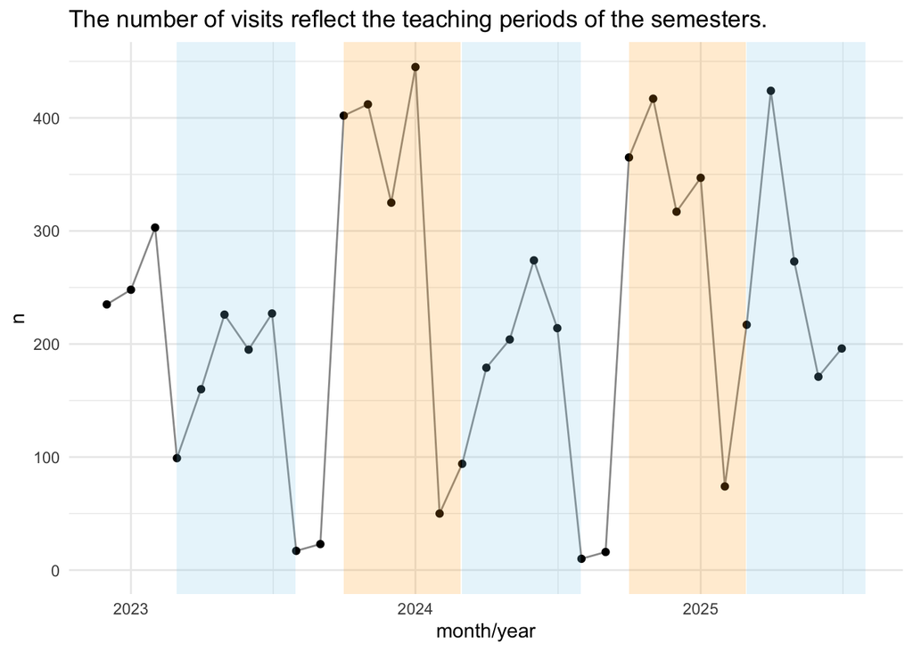

```r
time_visit_wday_summary_fingerprint_unique |>
  group_by(year_num, month_start) |>
  summarise(n = n()) |>
  ggplot(aes(x = month_start, y = n)) +
  geom_line(group = 1, color = "grey60") +
  geom_point() +
  labs(
    title = "The number of visits reflect the teaching periods of the semesters.",
    x = "month/year"
  ) +

  # --- Highlight March–July (approx 1 Mar to 31 Jul) ---
  annotate(
    "rect",
    xmin = as.Date("2023-03-01"),
    xmax = as.Date("2023-07-31"),
    ymin = -Inf,
    ymax = Inf,
    alpha = 0.2,
    fill = "skyblue"
  ) +

  annotate(
    "rect",
    xmin = as.Date("2024-03-01"),
    xmax = as.Date("2024-07-31"),
    ymin = -Inf,
    ymax = Inf,
    alpha = 0.2,
    fill = "skyblue"
  ) +
  annotate(
    "rect",
    xmin = as.Date("2025-03-01"),
    xmax = as.Date("2025-07-31"),
    ymin = -Inf,
    ymax = Inf,
    alpha = 0.2,
    fill = "skyblue"
  ) +

  # --- Highlight October–February (semester break or 2nd term) ---
  annotate(
    "rect",
    xmin = as.Date("2023-10-01"),
    xmax = as.Date("2024-02-28"),
    ymin = -Inf,
    ymax = Inf,
    alpha = 0.2,
    fill = "orange"
  ) +
  # annotate("rect",
  #          xmin = as.Date("2024-10-01"), xmax = as.Date("2024-02-28"),
  #          ymin = -Inf, ymax = Inf, alpha = 0.2, fill = "orange") +
  annotate(
    "rect",
    xmin = as.Date("2024-10-01"),
    xmax = as.Date("2025-02-28"),
    ymin = -Inf,
    ymax = Inf,
    alpha = 0.2,
    fill = "orange"
  )
```

### 3.4.2 Visits im Zeitverlauf - pro Woche

```r
time_visit_wday_summary_week <-
  time_visit_wday |>
  ungroup() |>
  mutate(week_start = floor_date(date_time, "week")) |>
  mutate(week_num = week(date_time), year_num = year(date_time))
```

```r
time_visit_wday_summary_week_summarized <-
  time_visit_wday_summary_week |>
  group_by(year_num, week_num) |>
  summarise(n = n())

time_visit_wday_summary_week_summarized
```

| year_num | week_num | n |
| --- | --- | --- |
| 2022 | 49 | 67 |
| 2022 | 50 | 119 |
| 2022 | 51 | 83 |
| 2022 | 52 | 50 |
| 2022 | 53 | 10 |
| 2023 | 1 | 53 |
| 2023 | 2 | 91 |
| 2023 | 3 | 121 |
| 2023 | 4 | 90 |
| 2023 | 5 | 387 |

[output cut: 129 more lines]

```r
time_visit_wday_summary_week_summarized_dateformat <-
  time_visit_wday_summary_week |>
  group_by(week_start) |>
  summarise(n = n())
```

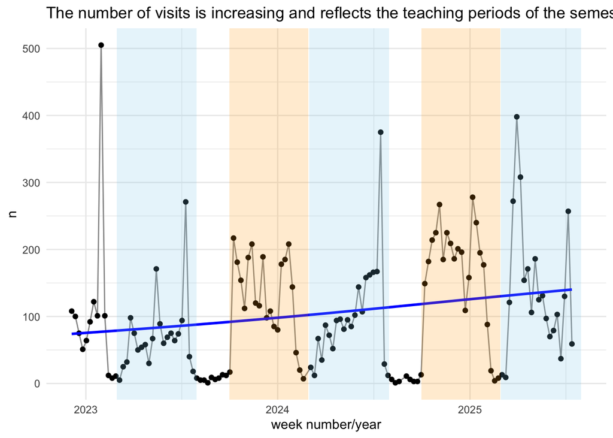

```r
time_visit_wday_summary_week_summarized_dateformat |>
  ggplot(aes(x = week_start, y = n)) +
  geom_line(group = 1, color = "grey60") +
  geom_point() +
  geom_smooth(method = "gam", se = FALSE, color = "blue") +
  labs(
    title = "The number of visits is increasing and reflects the teaching periods of the semesters.",
    x = "week number/year"
  ) +

  # --- Highlight March–July (approx 1 Mar to 31 Jul) ---
  annotate(
    "rect",
    xmin = as.Date("2023-03-01"),
    xmax = as.Date("2023-07-31"),
    ymin = -Inf,
    ymax = Inf,
    alpha = 0.2,
    fill = "skyblue"
  ) +

  annotate(
    "rect",
    xmin = as.Date("2024-03-01"),
    xmax = as.Date("2024-07-31"),
    ymin = -Inf,
    ymax = Inf,
    alpha = 0.2,
    fill = "skyblue"
  ) +
  annotate(
    "rect",
    xmin = as.Date("2025-03-01"),
    xmax = as.Date("2025-07-31"),
    ymin = -Inf,
    ymax = Inf,
    alpha = 0.2,
    fill = "skyblue"
  ) +

  # --- Highlight October–February (semester break or 2nd term) ---
  annotate(
    "rect",
    xmin = as.Date("2023-10-01"),
    xmax = as.Date("2024-02-28"),
    ymin = -Inf,
    ymax = Inf,
    alpha = 0.2,
    fill = "orange"
  ) +
  # annotate("rect",
  #          xmin = as.Date("2024-10-01"), xmax = as.Date("2024-02-28"),
  #          ymin = -Inf, ymax = Inf, alpha = 0.2, fill = "orange") +
  annotate(
    "rect",
    xmin = as.Date("2024-10-01"),
    xmax = as.Date("2025-02-28"),
    ymin = -Inf,
    ymax = Inf,
    alpha = 0.2,
    fill = "orange"
  )
```

**Wichtig**

The number of visits has increased over time.

### 3.4.3 Akkumulierte Seitenaufrufe im Zeitverlauf

#### 3.4.3.1 Monat - idvisit

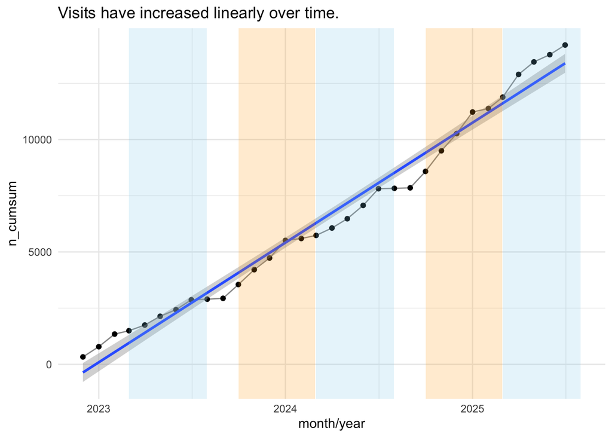

```r
time_visit_wday_summary |>
  group_by(year_num, month_start) |>
  summarise(n = n()) |>
  ungroup() |>
  mutate(n_cumsum = cumsum(n)) |>
  ggplot(aes(x = month_start, y = n_cumsum)) +
  geom_line(group = 1, color = "grey60") +
  geom_point() +
  theme_minimal() +
  geom_smooth(method = "lm") +
  labs(title = "Visits have increased linearly over time.", x = "month/year") +
  annotate(
    "rect",
    xmin = as.Date("2023-03-01"),
    xmax = as.Date("2023-07-31"),
    ymin = -Inf,
    ymax = Inf,
    alpha = 0.2,
    fill = "skyblue"
  ) +

  annotate(
    "rect",
    xmin = as.Date("2024-03-01"),
    xmax = as.Date("2024-07-31"),
    ymin = -Inf,
    ymax = Inf,
    alpha = 0.2,
    fill = "skyblue"
  ) +
  annotate(
    "rect",
    xmin = as.Date("2025-03-01"),
    xmax = as.Date("2025-07-31"),
    ymin = -Inf,
    ymax = Inf,
    alpha = 0.2,
    fill = "skyblue"
  ) +

  # --- Highlight October–February (semester break or 2nd term) ---
  annotate(
    "rect",
    xmin = as.Date("2023-10-01"),
    xmax = as.Date("2024-02-28"),
    ymin = -Inf,
    ymax = Inf,
    alpha = 0.2,
    fill = "orange"
  ) +
  # annotate("rect",
  #          xmin = as.Date("2024-10-01"), xmax = as.Date("2024-02-28"),
  #          ymin = -Inf, ymax = Inf, alpha = 0.2, fill = "orange") +
  annotate(
    "rect",
    xmin = as.Date("2024-10-01"),
    xmax = as.Date("2025-02-28"),
    ymin = -Inf,
    ymax = Inf,
    alpha = 0.2,
    fill = "orange"
  )
```

#### 3.4.3.2 Monat - fingerprint

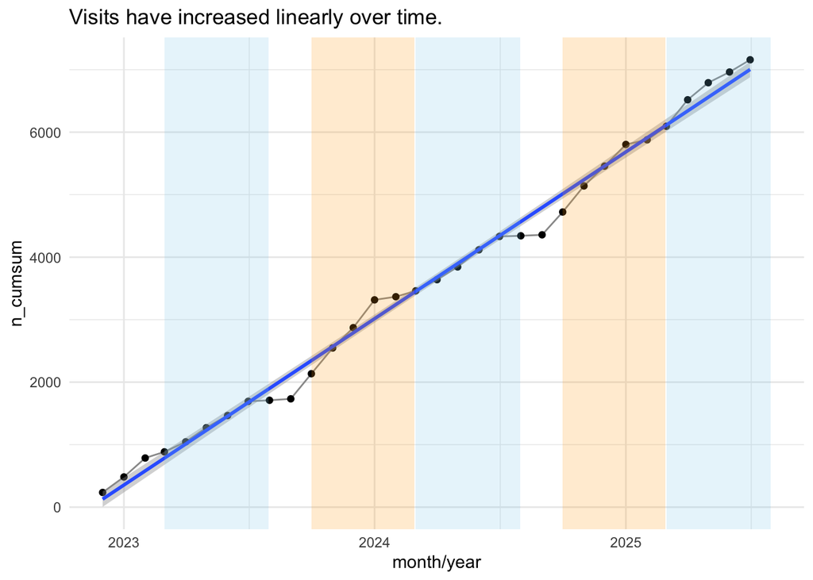

```r
time_visit_wday_summary_fingerprint |>
  group_by(year_num, month_start) |>
  summarise(n = n()) |>
  ungroup() |>
  mutate(n_cumsum = cumsum(n)) |>
  ggplot(aes(x = month_start, y = n_cumsum)) +
  geom_line(group = 1, color = "grey60") +
  geom_point() +
  theme_minimal() +
  geom_smooth(method = "lm") +
  labs(title = "Visits have increased linearly over time.", x = "month/year") +
  labs(title = "Visits have increased linearly over time.", x = "month/year") +
  annotate(
    "rect",
    xmin = as.Date("2023-03-01"),
    xmax = as.Date("2023-07-31"),
    ymin = -Inf,
    ymax = Inf,
    alpha = 0.2,
    fill = "skyblue"
  ) +

  annotate(
    "rect",
    xmin = as.Date("2024-03-01"),
    xmax = as.Date("2024-07-31"),
    ymin = -Inf,
    ymax = Inf,
    alpha = 0.2,
    fill = "skyblue"
  ) +
  annotate(
    "rect",
    xmin = as.Date("2025-03-01"),
    xmax = as.Date("2025-07-31"),
    ymin = -Inf,
    ymax = Inf,
    alpha = 0.2,
    fill = "skyblue"
  ) +

  # --- Highlight October–February (semester break or 2nd term) ---
  annotate(
    "rect",
    xmin = as.Date("2023-10-01"),
    xmax = as.Date("2024-02-28"),
    ymin = -Inf,
    ymax = Inf,
    alpha = 0.2,
    fill = "orange"
  ) +
  # annotate("rect",
  #          xmin = as.Date("2024-10-01"), xmax = as.Date("2024-02-28"),
  #          ymin = -Inf, ymax = Inf, alpha = 0.2, fill = "orange") +
  annotate(
    "rect",
    xmin = as.Date("2024-10-01"),
    xmax = as.Date("2025-02-28"),
    ymin = -Inf,
    ymax = Inf,
    alpha = 0.2,
    fill = "orange"
  )
```

#### 3.4.3.3 Monat - fingerprint unique

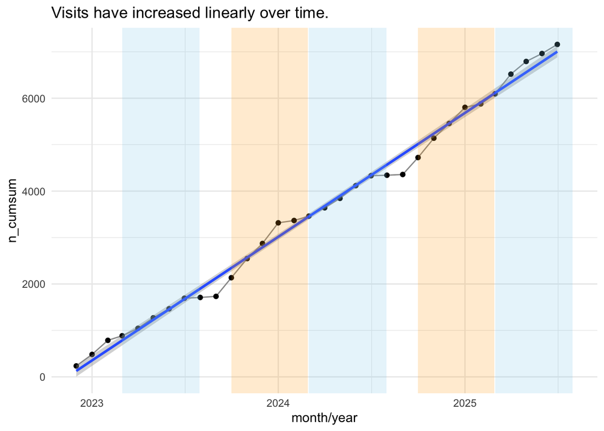

```r
time_visit_wday_summary_fingerprint_unique |>
  group_by(year_num, month_start) |>
  summarise(n = n()) |>
  ungroup() |>
  mutate(n_cumsum = cumsum(n)) |>
  ggplot(aes(x = month_start, y = n_cumsum)) +
  geom_line(group = 1, color = "grey60") +
  geom_point() +
  theme_minimal() +
  geom_smooth(method = "lm") +
  labs(title = "Visits have increased linearly over time.", x = "month/year") +
  labs(title = "Visits have increased linearly over time.", x = "month/year") +
  annotate(
    "rect",
    xmin = as.Date("2023-03-01"),
    xmax = as.Date("2023-07-31"),
    ymin = -Inf,
    ymax = Inf,
    alpha = 0.2,
    fill = "skyblue"
  ) +

  annotate(
    "rect",
    xmin = as.Date("2024-03-01"),
    xmax = as.Date("2024-07-31"),
    ymin = -Inf,
    ymax = Inf,
    alpha = 0.2,
    fill = "skyblue"
  ) +
  annotate(
    "rect",
    xmin = as.Date("2025-03-01"),
    xmax = as.Date("2025-07-31"),
    ymin = -Inf,
    ymax = Inf,
    alpha = 0.2,
    fill = "skyblue"
  ) +

  # --- Highlight October–February (semester break or 2nd term) ---
  annotate(
    "rect",
    xmin = as.Date("2023-10-01"),
    xmax = as.Date("2024-02-28"),
    ymin = -Inf,
    ymax = Inf,
    alpha = 0.2,
    fill = "orange"
  ) +
  # annotate("rect",
  #          xmin = as.Date("2024-10-01"), xmax = as.Date("2024-02-28"),
  #          ymin = -Inf, ymax = Inf, alpha = 0.2, fill = "orange") +
  annotate(
    "rect",
    xmin = as.Date("2024-10-01"),
    xmax = as.Date("2025-02-28"),
    ymin = -Inf,
    ymax = Inf,
    alpha = 0.2,
    fill = "orange"
  )
```

#### 3.4.3.4 Woche

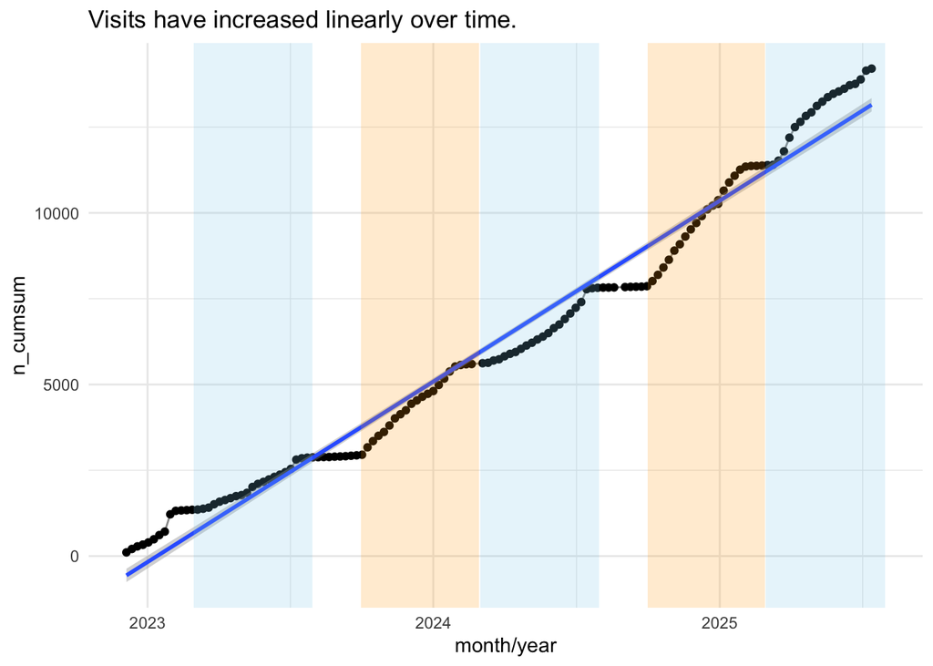

```r
time_visit_wday_summary_week |>
  group_by(year_num, week_start) |>
  summarise(n = n()) |>
  ungroup() |>
  mutate(n_cumsum = cumsum(n)) |>
  ggplot(aes(x = week_start, y = n_cumsum)) +
  geom_line(group = 1, color = "grey60") +
  geom_point() +
  theme_minimal() +
  geom_smooth(method = "lm") +
  labs(
    title = "Visits have increased approx. linearly over time.",
    x = "week/year"
  ) +
  labs(title = "Visits have increased linearly over time.", x = "month/year") +
  annotate(
    "rect",
    xmin = as.Date("2023-03-01"),
    xmax = as.Date("2023-07-31"),
    ymin = -Inf,
    ymax = Inf,
    alpha = 0.2,
    fill = "skyblue"
  ) +

  annotate(
    "rect",
    xmin = as.Date("2024-03-01"),
    xmax = as.Date("2024-07-31"),
    ymin = -Inf,
    ymax = Inf,
    alpha = 0.2,
    fill = "skyblue"
  ) +
  annotate(
    "rect",
    xmin = as.Date("2025-03-01"),
    xmax = as.Date("2025-07-31"),
    ymin = -Inf,
    ymax = Inf,
    alpha = 0.2,
    fill = "skyblue"
  ) +

  # --- Highlight October–February (semester break or 2nd term) ---
  annotate(
    "rect",
    xmin = as.Date("2023-10-01"),
    xmax = as.Date("2024-02-28"),
    ymin = -Inf,
    ymax = Inf,
    alpha = 0.2,
    fill = "orange"
  ) +
  # annotate("rect",
  #          xmin = as.Date("2024-10-01"), xmax = as.Date("2024-02-28"),
  #          ymin = -Inf, ymax = Inf, alpha = 0.2, fill = "orange") +
  annotate(
    "rect",
    xmin = as.Date("2024-10-01"),
    xmax = as.Date("2025-02-28"),
    ymin = -Inf,
    ymax = Inf,
    alpha = 0.2,
    fill = "orange"
  )
```

## 3.5 Statistiken

Die folgenden Statistiken beruhen auf dem Datensatz `data_separated_filtered`:

### 3.5.1 idivisit

```r
glimpse(data_separated_filtered)
```

```
Rows: 4,477,584
Columns: 5
$ nr          <int> 0, 0, 1, 1, 1, 1, 2, 2, 3, 3, 3, 3, 4, 4, 4, 4, 5, 5, 5, 5…
$ type        <fct> subtitle, timestamp, eventcategory, eventaction, timestamp…
$ value       <fct> "https://hans.th-nuernberg.de/", "2023-03-23 18:37:56", "c…
$ idvisit     <int> 1, 1, 1, 1, 1, 1, 1, 1, 1, 1, 1, 1, 1, 1, 1, 1, 1, 1, 1, 1…
$ fingerprint <fct> aa8a78771b4f21ff, aa8a78771b4f21ff, aa8a78771b4f21ff, aa8a…
```

`nr` fasst die Nummer der Aktion innerhalb eines bestimmten Visits.

### 3.5.2 fingerprint unique

```r
data_separated_filtered |>
  distinct(fingerprint, .keep_all = TRUE) |>
  glimpse()
```

```
Rows: 7,160
Columns: 5
$ nr          <int> 0, 0, 0, 0, 0, 0, 0, 0, 0, 0, 0, 0, 0, 0, 0, 0, 0, 0, 0, 0…
$ type        <fct> subtitle, subtitle, subtitle, subtitle, subtitle, subtitle…
$ value       <fct> "https://hans.th-nuernberg.de/", "https://hans.th-nuernber…
$ idvisit     <int> 1, 3, 6, 7, 8, 10, 15, 16, 17, 18, 19, 20, 21, 22, 23, 24,…
$ fingerprint <fct> aa8a78771b4f21ff, 1f026ad3cbbdf325, 518965d4e1ae7e2d, aa95…
```

## 3.6 Mit allen Daten (den 499er-Daten)

### 3.6.1 idvisit

```r
tbl_n_action <-
  n_action |>
  describe_distribution(nr_max, centrality = c("median", "mean"))

tbl_n_action
```

| Variable | Median | MAD | Mean | SD | IQR | Min | Max | Skewness | Kurtosis | n | n_Missing |
| --- | --- | --- | --- | --- | --- | --- | --- | --- | --- | --- | --- |
| nr_max | 27 | 37.065 | 79.75202 | 122.5267 | 88 | 1 | 499 | 2.23625 | 4.40704 | 14207 | 0 |

`nr_max` gibt den Maximalwert von `nr` zurück, sagt also, wie viele Aktionen maximal während eines Vitis ausgeführt wurden.

Betrachtet man die Anzahl der Aktionen pro Visit näher, so fällt auf, dass der Maximalwert (499) sehr häufig vorkommt:

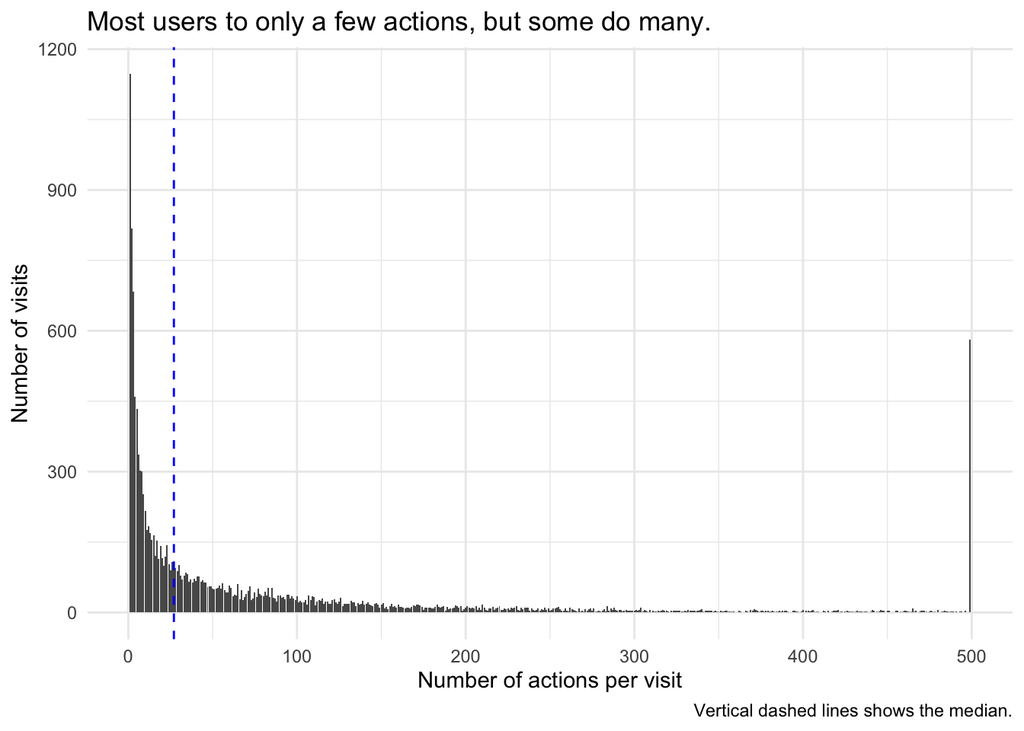

```r
n_action |>
  count(nr_max) |>
  ggplot(aes(x = nr_max, y = n)) +
  geom_col() +
  geom_vline(
    xintercept = tbl_n_action$Median,
    color = "blue",
    linetype = "dashed"
  ) +
  labs(
    caption = "Vertical dashed lines shows the median.",
    title = "Most users to only a few actions, but some do many.",
    x = "Number of actions per visit",
    y = "Number of visits"
  )
```

**Wichtig**

Die meisten Nutzer machen nur wenige Aktionen pro Visit, aber einige machen sehr viele.

Hier noch in einer anderen Darstellung:

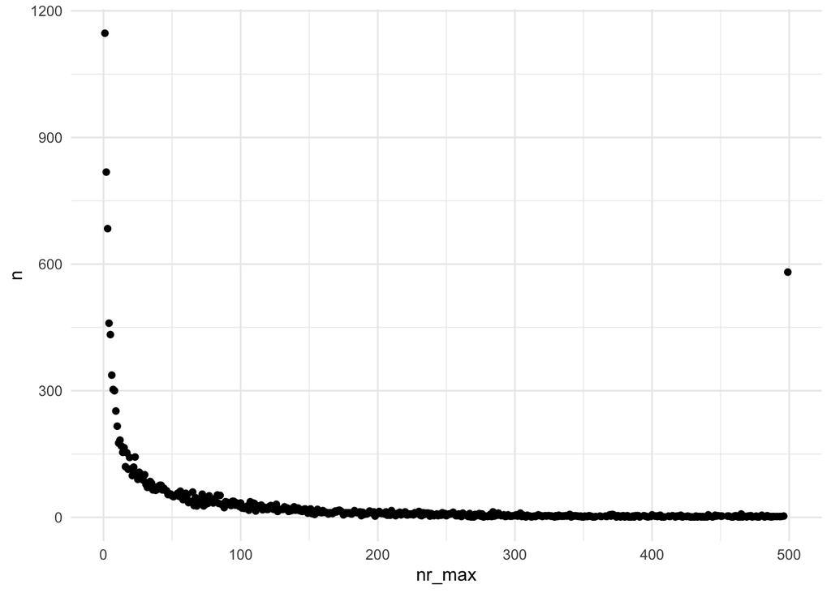

```r
n_action |>
  count(nr_max) |>
  ggplot(aes(x = nr_max, y = n)) +
  geom_point()
```

Der Maximalwert ist einfach auffällig häufig:

```r
n_action |>
  count(nr_max == 499) |>
  gt()
```

| nr_max == 499 | n |
| --- | --- |
| FALSE | 13626 |
| TRUE | 581 |

Es erscheint plausibel, dass der Maximalwert alle “gekappten” (*zensierten*, abgeschnittenen) Werte fasst, also viele Werte, die eigentlich größer wären (aber dann zensiert wurden).

### 3.6.2 fingerprint

```r
tbl_n_action_fingerprint <-
  n_action_fingerprint |>
  describe_distribution(nr_max, centrality = c("median", "mean"))

tbl_n_action_fingerprint
```

| Variable | Median | MAD | Mean | SD | IQR | Min | Max | Skewness | Kurtosis | n | n_Missing |
| --- | --- | --- | --- | --- | --- | --- | --- | --- | --- | --- | --- |
| nr_max | 38 | 51.891 | 98.775 | 136.419 | 119 | 1 | 499 | 1.807791 | 2.351025 | 7160 | 0 |

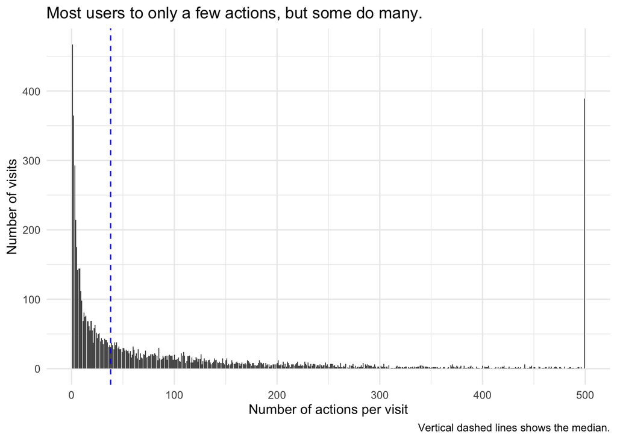

```r
n_action_fingerprint |>
  count(nr_max) |>
  ggplot(aes(x = nr_max, y = n)) +
  geom_col() +
  geom_vline(
    xintercept = tbl_n_action_fingerprint$Median,
    color = "blue",
    linetype = "dashed"
  ) +
  labs(
    caption = "Vertical dashed lines shows the median.",
    title = "Most users to only a few actions, but some do many.",
    x = "Number of actions per visit",
    y = "Number of visits"
  )
```

### 3.6.3 fingerprint unique

```r
tbl_n_action_fingerprint_unique <-
  n_action_fingerprint |>
  distinct(fingerprint, .keep_all = TRUE)

tbl_n_action_fingerprint_unique |>
  describe_distribution(nr_max, centrality = c("median", "mean"))
```

| Variable | Median | MAD | Mean | SD | IQR | Min | Max | Skewness | Kurtosis | n | n_Missing |
| --- | --- | --- | --- | --- | --- | --- | --- | --- | --- | --- | --- |
| nr_max | 38 | 51.891 | 98.775 | 136.419 | 119 | 1 | 499 | 1.807791 | 2.351025 | 7160 | 0 |

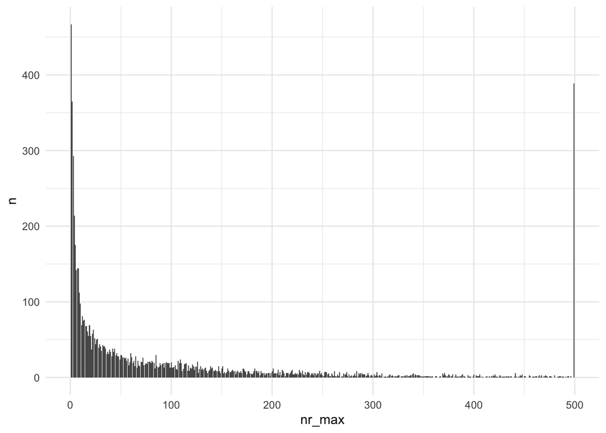

```r
tbl_n_action_fingerprint_unique |>
  count(nr_max) |>
  ggplot(aes(x = nr_max, y = n)) +
  geom_col() +
  geom_vline(
    xintercept = tbl_n_action_fingerprint_unique$Median,
    color = "blue",
    linetype = "dashed"
  )
```

## 3.7 Nur Visitors, für die weniger als 500 Aktionen protokolliert sind

### 3.7.1 idvisit

```r
n_action_lt_500 |>
  describe_distribution(nr_max) |>
  gt() |>
  fmt_number(columns = where(is.numeric), decimals = 2)
```

| Variable | Mean | SD | IQR | Min | Max | Skewness | Kurtosis | n | n_Missing |
| --- | --- | --- | --- | --- | --- | --- | --- | --- | --- |
| nr_max | 61.88 | 88.53 | 77.00 | 1.00 | 496.00 | 2.27 | 5.47 | 13,626.00 | 0.00 |

### 3.7.2 fingerprint

```r
n_action_lt_500_fingerprint |>
  describe_distribution(nr_max) |>
  gt() |>
  fmt_number(columns = where(is.numeric), decimals = 2)
```

| Variable | Mean | SD | IQR | Min | Max | Skewness | Kurtosis | n | n_Missing |
| --- | --- | --- | --- | --- | --- | --- | --- | --- | --- |
| nr_max | 75.78 | 99.73 | 100.00 | 1.00 | 496.00 | 1.88 | 3.31 | 6,771.00 | 0.00 |

### 3.7.3 fingerprint unique

```r
n_action_lt_500_fingerprint_unique <-
  n_action_fingerprint |>
  filter(nr_max != 499) |>
  distinct(fingerprint, .keep_all = TRUE)

n_action_lt_500_fingerprint_unique |>
  describe_distribution(nr_max) |>
  gt() |>
  fmt_number(columns = where(is.numeric), decimals = 2)
```

| Variable | Mean | SD | IQR | Min | Max | Skewness | Kurtosis | n | n_Missing |
| --- | --- | --- | --- | --- | --- | --- | --- | --- | --- |
| nr_max | 75.78 | 99.73 | 100.00 | 1.00 | 496.00 | 1.88 | 3.31 | 6,771.00 | 0.00 |

## 3.8 An welchen Tagen und zu welcher Zeit kommen die User zu HaNS?

### 3.8.1 Setup

#### 3.8.1.1 idvisit

```r
# Define a vector with the names of the days of the week
# Note: Adjust the start of the week (Sunday or Monday) as per your requirement
days_of_week <- c(
  "Monday",
  "Tuesday",
  "Wednesday",
  "Thursday",
  "Friday",
  "Saturday",
  "Sunday"
)

# Replace numbers with day names
time_visit_wday$dow2 <- factor(
  days_of_week[time_visit_wday$dow],
  levels = days_of_week
)
```

#### 3.8.1.2 fingerprint

```r
# Define a vector with the names of the days of the week
# Note: Adjust the start of the week (Sunday or Monday) as per your requirement
days_of_week <- c(
  "Monday",
  "Tuesday",
  "Wednesday",
  "Thursday",
  "Friday",
  "Saturday",
  "Sunday"
)

# Replace numbers with day names
time_visit_wday_fingerprint$dow2 <- factor(
  days_of_week[time_visit_wday_fingerprint$dow],
  levels = days_of_week
)
```

### 3.8.2 HaNS-Login nach Uhrzeit

#### 3.8.2.1 idvisit

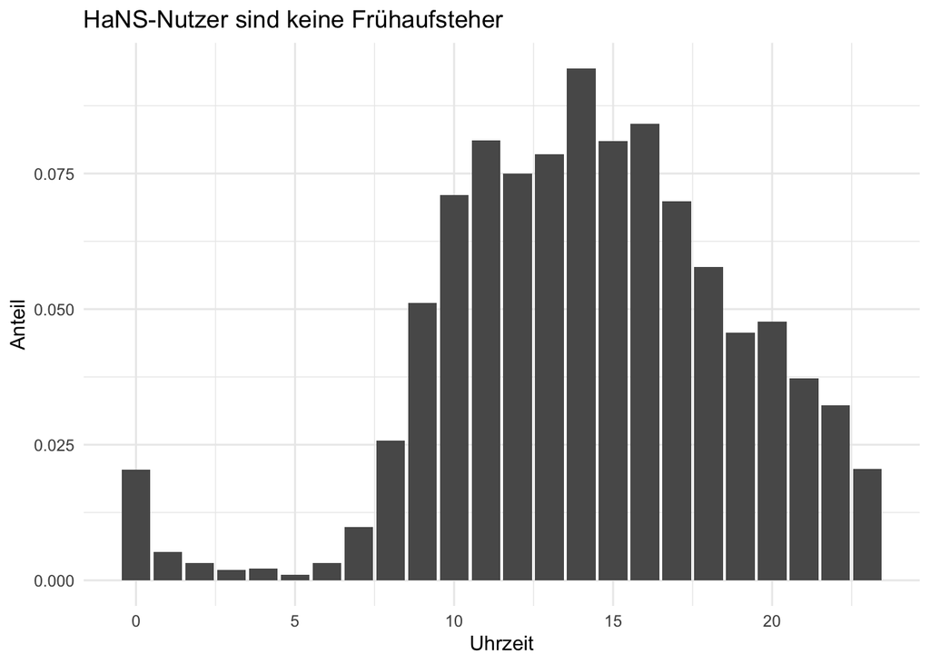

```r
time_visit_wday |>
  as_tibble() |>
  count(hour) |>
  mutate(prop = n / sum(n)) |>
  ggplot(aes(x = hour, y = prop)) +
  geom_col() +
  theme_minimal() +
  labs(
    title = "HaNS-Nutzer sind keine Frühaufsteher",
    x = "Uhrzeit",
    y = "Anteil"
  )
```

```r
# coord_polar()
```

#### 3.8.2.2 fingerprint unique

[figure not shown]

```r
time_visit_wday_summary_fingerprint |>
  as_tibble() |>
  distinct(hour, .keep_all = TRUE) |>
  count(hour) |>
  mutate(prop = n / sum(n)) |>
  ggplot(aes(x = hour, y = prop)) +
  geom_col() +
  theme_minimal() +
  labs(
    title = "HaNS-Nutzer sind keine Frühaufsteher",
    x = "Uhrzeit",
    y = "Anteil"
  )
```

```r
# coord_polar()
```

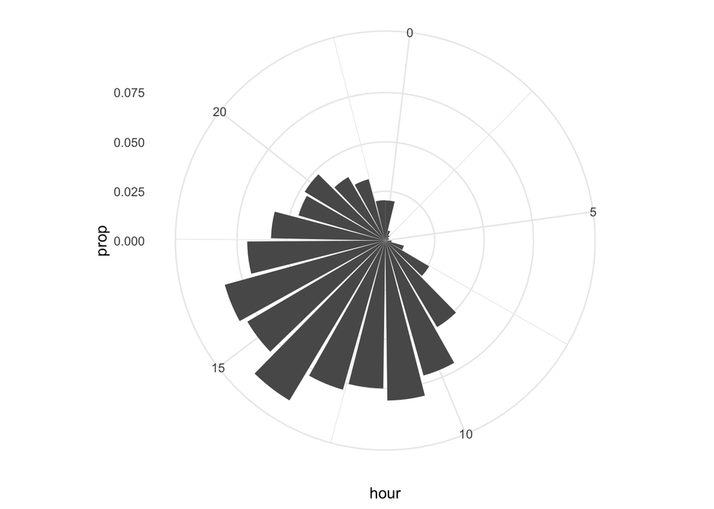

```r
time_visit_wday |>
  as_tibble() |>
  count(hour) |>
  mutate(prop = n / sum(n)) |>
  ggplot(aes(x = hour, y = prop)) +
  geom_col() +
  theme_minimal() +
  coord_polar()
```

### 3.8.3 Verteilung der HaNS-Besuche nach Wochentagen

#### 3.8.3.1 idvisit

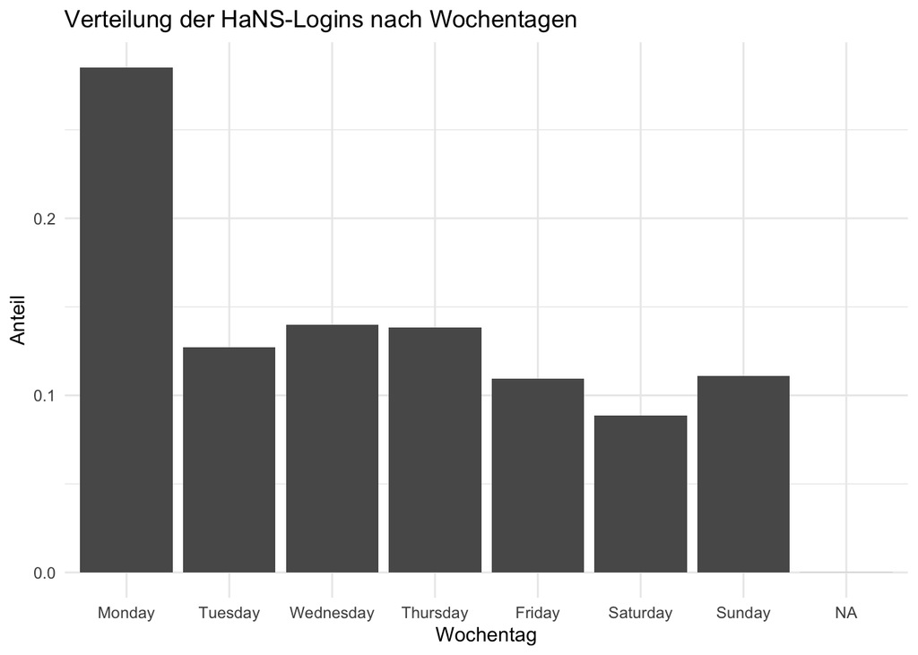

```r
time_visit_wday |>
  as_tibble() |>
  count(dow2) |>
  mutate(prop = n / sum(n)) |>
  ggplot(aes(x = dow2, y = prop)) +
  geom_col() +
  theme_minimal() +
  labs(
    title = "Verteilung der HaNS-Logins nach Wochentagen",
    x = "Wochentag",
    y = "Anteil"
  )
```

```r
# coord_polar()
```

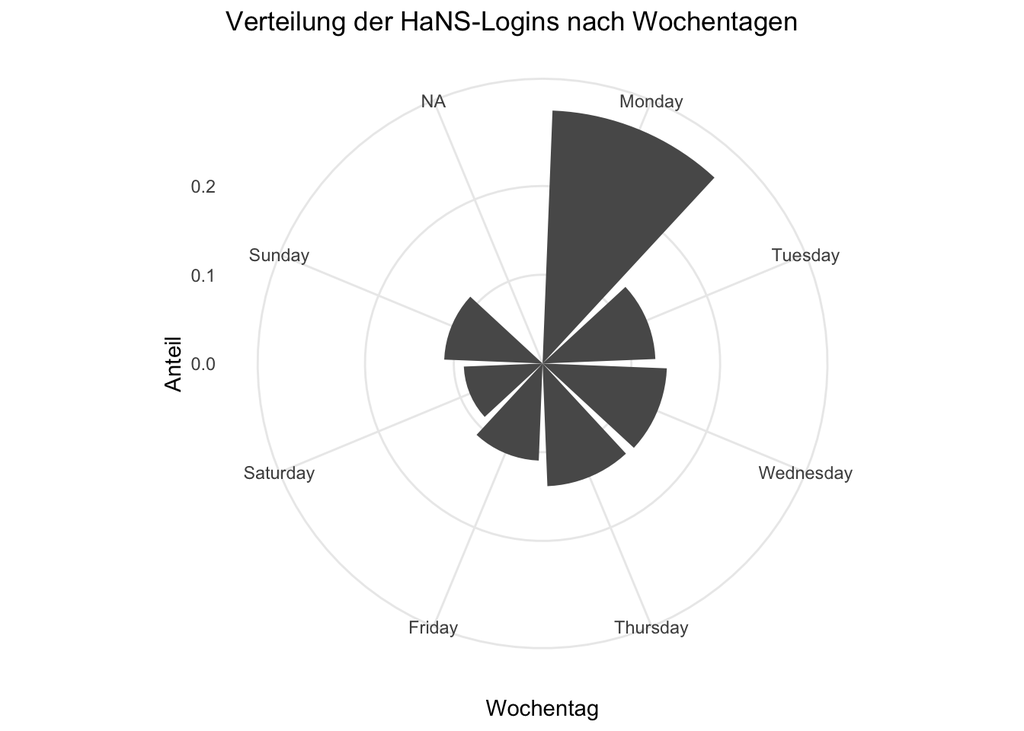

```r
time_visit_wday |>
  as_tibble() |>
  count(dow2) |>
  mutate(prop = n / sum(n)) |>
  ggplot(aes(x = dow2, y = prop)) +
  geom_col() +
  theme_minimal() +
  labs(
    title = "Verteilung der HaNS-Logins nach Wochentagen",
    x = "Wochentag",
    y = "Anteil"
  ) +
  coord_polar()
```

##### 3.8.3.1.1 fingerprint

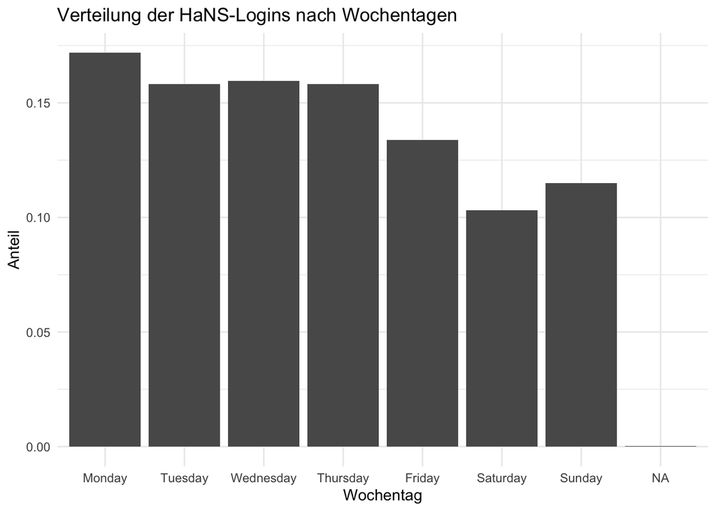

```r
time_visit_wday_fingerprint |>
  as_tibble() |>
  distinct(fingerprint, .keep_all = TRUE) |>
  count(dow2) |>
  mutate(prop = n / sum(n)) |>
  ggplot(aes(x = dow2, y = prop)) +
  geom_col() +
  theme_minimal() +
  labs(
    title = "Verteilung der HaNS-Logins nach Wochentagen",
    x = "Wochentag",
    y = "Anteil"
  )
```

```r
# coord_polar()
```

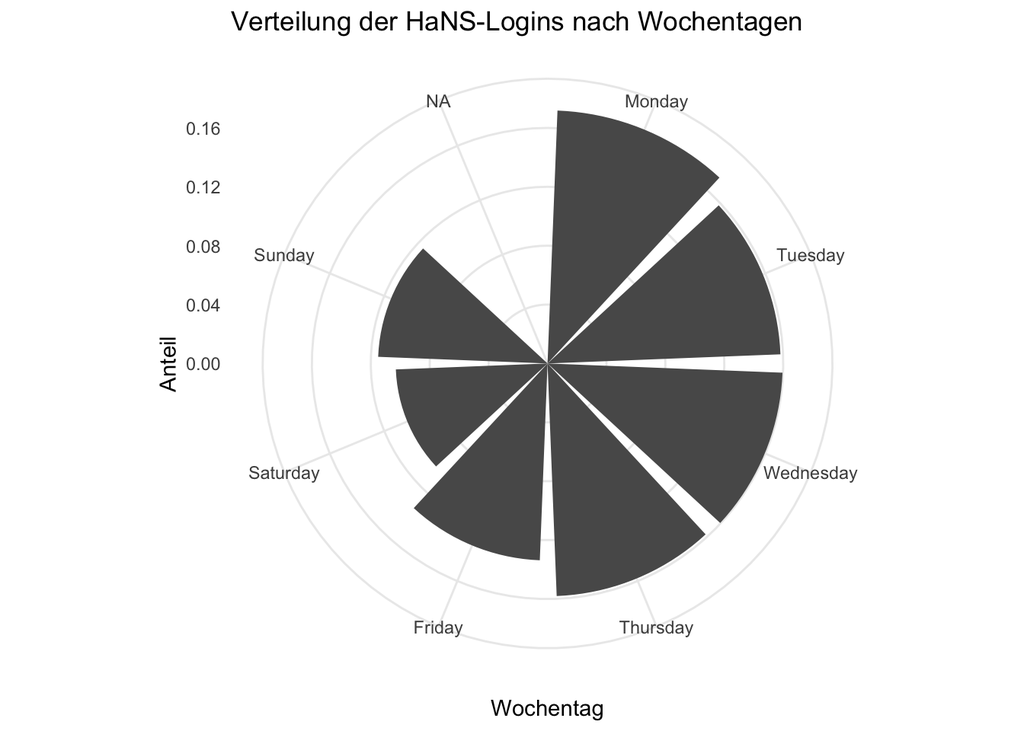

```r
time_visit_wday_fingerprint |>
  as_tibble() |>
  distinct(fingerprint, .keep_all = TRUE) |>
  count(dow2) |>
  mutate(prop = n / sum(n)) |>
  ggplot(aes(x = dow2, y = prop)) +
  geom_col() +
  theme_minimal() +
  labs(
    title = "Verteilung der HaNS-Logins nach Wochentagen",
    x = "Wochentag",
    y = "Anteil"
  ) +
  coord_polar()
```

#### 3.8.3.2 HaNS-Login nach Wochentagen Uhrzeit

##### 3.8.3.2.1 idvisit

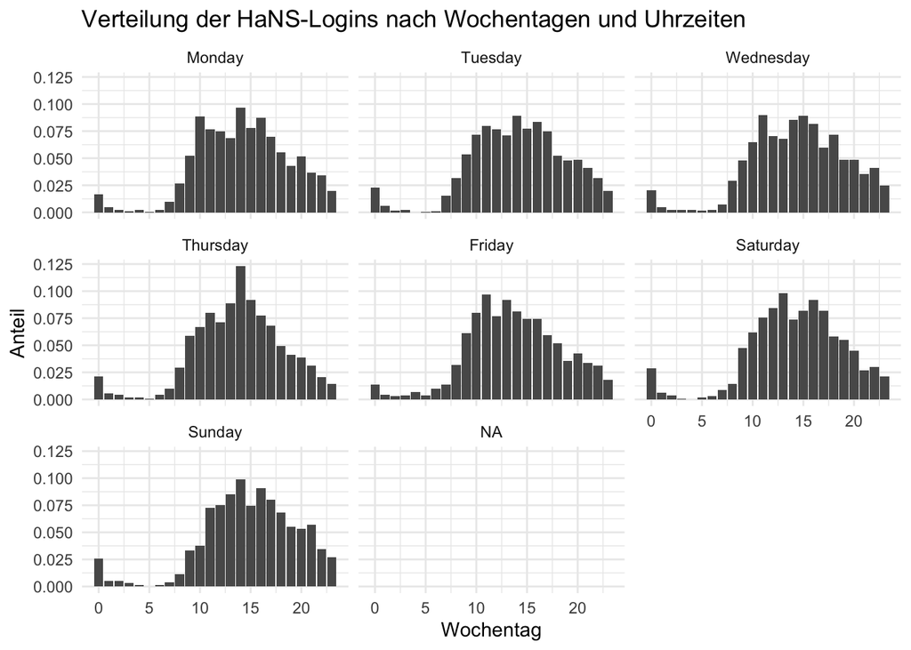

```r
time_visit_wday |>
  as_tibble() |>
  count(dow2, hour) |>
  group_by(dow2) |>
  mutate(prop = n / sum(n)) |>
  ggplot(aes(x = hour, y = prop)) +
  geom_col() +
  facet_wrap(~dow2) +
  theme_minimal() +
  labs(
    title = "Verteilung der HaNS-Logins nach Wochentagen und Uhrzeiten",
    x = "Wochentag",
    y = "Anteil"
  )
```

```r
# coord_polar()
```

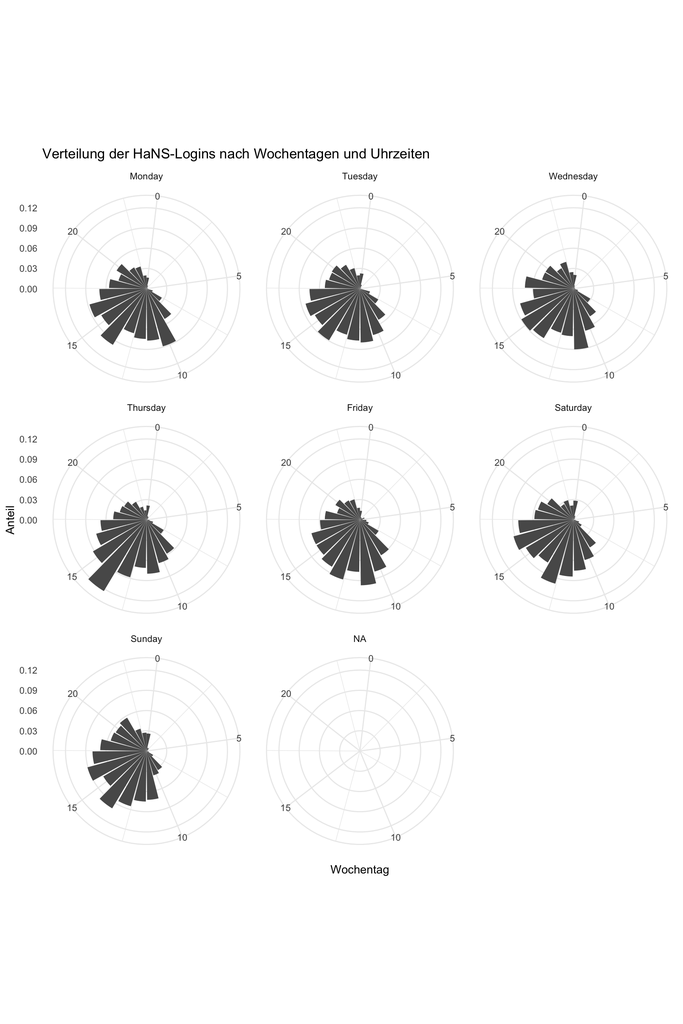

```r
time_visit_wday |>
  as_tibble() |>
  count(dow2, hour) |>
  group_by(dow2) |>
  mutate(prop = n / sum(n)) |>
  ggplot(aes(x = hour, y = prop)) +
  geom_col() +
  facet_wrap(~dow2) +
  theme_minimal() +
  labs(
    title = "Verteilung der HaNS-Logins nach Wochentagen und Uhrzeiten",
    x = "Wochentag",
    y = "Anteil"
  ) +
  coord_polar()
```

##### 3.8.3.2.2 fingerprint

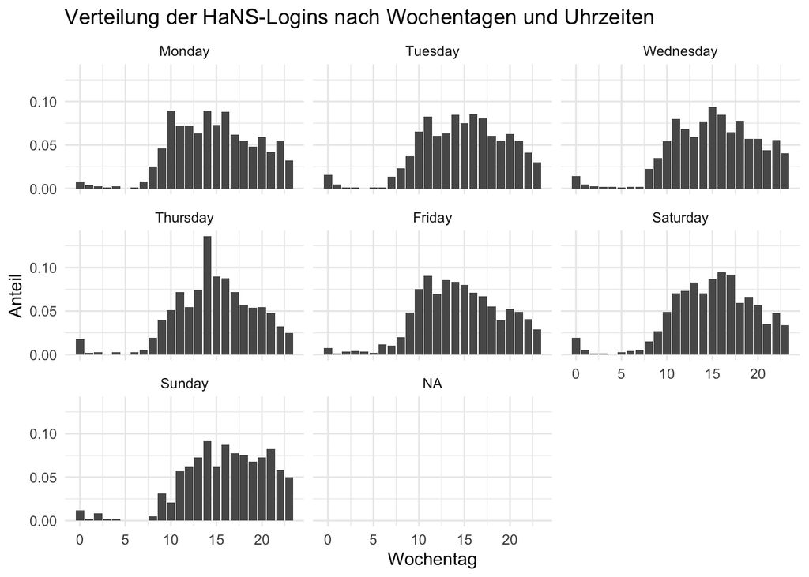

```r
time_visit_wday_fingerprint |>
  as_tibble() |>
  distinct(fingerprint, .keep_all = TRUE) |>
  count(dow2, hour) |>
  group_by(dow2) |>
  mutate(prop = n / sum(n)) |>
  ggplot(aes(x = hour, y = prop)) +
  geom_col() +
  facet_wrap(~dow2) +
  theme_minimal() +
  labs(
    title = "Verteilung der HaNS-Logins nach Wochentagen und Uhrzeiten",
    x = "Wochentag",
    y = "Anteil"
  )
```

```r
# coord_polar()
```

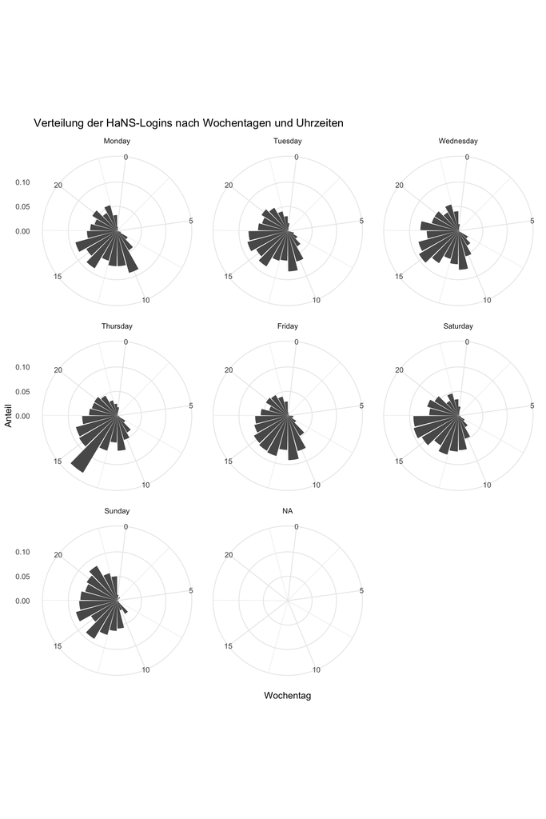

```r
time_visit_wday_fingerprint |>
  as_tibble() |>
  distinct(fingerprint, .keep_all = TRUE) |>
  count(dow2, hour) |>
  group_by(dow2) |>
  mutate(prop = n / sum(n)) |>
  ggplot(aes(x = hour, y = prop)) +
  geom_col() +
  facet_wrap(~dow2) +
  theme_minimal() +
  labs(
    title = "Verteilung der HaNS-Logins nach Wochentagen und Uhrzeiten",
    x = "Wochentag",
    y = "Anteil"
  ) +
  coord_polar()
```